# STA 631: Statistical Modeling I - Final Portfolio

Steve Meadows

2025-12-07

# 1 Introduction

This portfolio summarizes my learning and accomplishments in STA 631: Statistical Modeling I. Throughout the course, I have developed a strong foundation in statistical modeling techniques, including probability theory, generalized linear models, model selection, and effective communication of statistical results. The following sections outline the key objectives of the course and how I have met them through various assignments and projects.

# 2 Part I: Linear and Poisson Regression Models

**Data Description: Student Social Media Addiction**

For the first component of this portfolio, I utilized the Student Social Media Addiction dataset sourced from [Kaggle](https://www.kaggle.com/datasets/rehan497/students-social-media-addiction). This dataset comprises survey responses from 705 students across multiple countries, offering a cross-sectional view of digital habits and psychological well-being.

The data captures a variety of behavioral and demographic metrics, including average daily social media usage, preferred platforms, sleep duration, and self-reported addiction scores. The primary outcome variable for this analysis is the Mental Health Score, a numeric indicator allowing us to explore how digital consumption patterns—specifically addiction levels and usage time—correlate with a student’s overall mental health.

Due to the nature of this dataset and the numeric outcome variable, I have chosen to apply a linear regression model to predict mental health scores based on various predictors related to social media addiction.

## 2.1 Exploratory Data Analysis

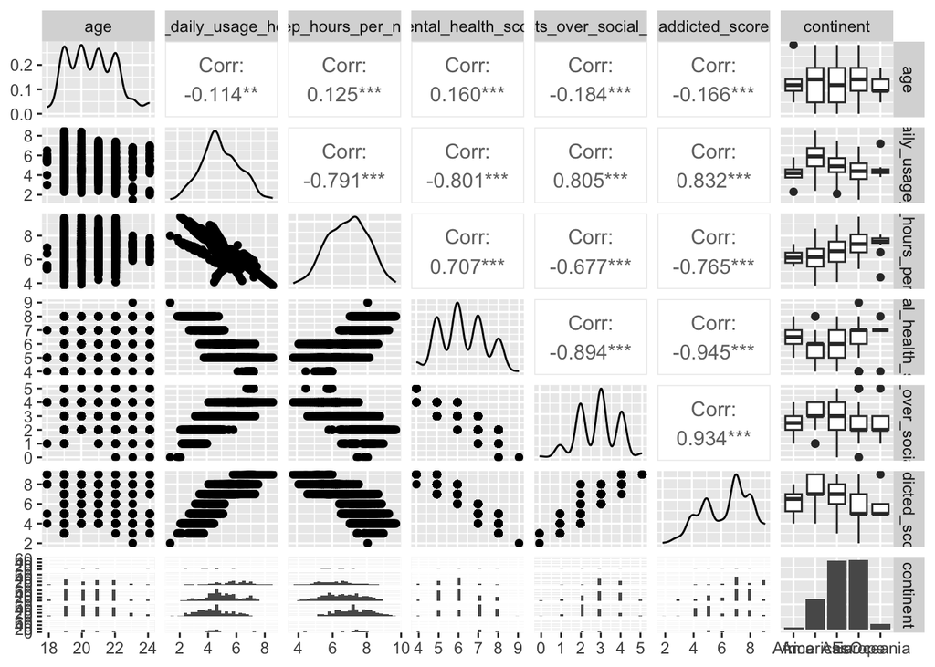

```r
# pairwise relationships for numeric variables
df |>
  dplyr::select(-student_id, -country, -academic_level, -most_used_platform, -relationship_status, -affects_academic_performance, -gender) |>
  ggpairs()
```

I was deliberating on which feature to use as my predictor variable for mental health score. After examining the pairwise relationships, I observed that “addicted_score” had a very strong correlation with “mental_health_score”. Therefore, I decided to use “mental_health_score” as my predictor variable for modeling.

## 2.2 Backward Selection Process

```r
# Remove ID, country, and addicted_score columns so they aren't treated as predictors
df_modeling <- df |>
  dplyr::select(-student_id, -country, -addicted_score)
# Set the Engine
lm_spec <- linear_reg() |>
  set_mode("regression") |>
  set_engine("lm")
m1 <- lm_spec |>
  fit(mental_health_score ~ ., data = df_modeling)

check_p(m1, title_text = "Round 1: Variables to Drop")
```

Round 1: Variables to Drop

| term | estimate | std.error | statistic | p.value |
| --- | --- | --- | --- | --- |
| sleep_hours_per_night | 0.001 | 0.031 | 0.028 | 0.978 |
| continentEurope | 0.025 | 0.185 | 0.134 | 0.894 |
| continentAmericas | 0.031 | 0.190 | 0.162 | 0.871 |
| most_used_platformLINE | −0.037 | 0.148 | −0.247 | 0.805 |
| continentAsia | −0.057 | 0.186 | −0.308 | 0.758 |
| relationship_statusSingle | 0.032 | 0.090 | 0.359 | 0.719 |
| most_used_platformInstagram | −0.021 | 0.057 | −0.376 | 0.707 |
| relationship_statusIn Relationship | −0.057 | 0.091 | −0.626 | 0.531 |
| most_used_platformKakaoTalk | 0.101 | 0.147 | 0.689 | 0.491 |
| most_used_platformSnapchat | −0.121 | 0.140 | −0.867 | 0.386 |
| age | −0.023 | 0.024 | −0.935 | 0.350 |
| continentOceania | 0.232 | 0.206 | 1.127 | 0.260 |
| most_used_platformWeChat | 0.155 | 0.126 | 1.228 | 0.220 |
| most_used_platformVKontakte | −0.215 | 0.135 | −1.596 | 0.111 |
| academic_levelUndergraduate | −0.123 | 0.076 | −1.624 | 0.105 |
| most_used_platformYouTube | −0.255 | 0.156 | −1.630 | 0.104 |

**Objective: Describe probability as a foundation of statistical modeling, including inference and maximum likelihood estimation**

Probability theory underpins statistical modeling by providing a framework to quantify uncertainty and make inferences about populations based on sample data. Just within the context of this first step of model selection, we are using p-values to determine the statistical significance of each predictor variable. A p-value represents the probability of observing the data, or something more extreme, under the null hypothesis that there is no effect or relationship. By setting a significance level (commonly 0.05), we can decide whether to reject or fail to reject the null hypothesis for each predictor. This process allows us to identify which variables have a statistically significant impact on the outcome variable, guiding us in building a more parsimonious and interpretable model.

Here we see that sleep_hours_per_night has the highest non-significant p-value of 0.98. Therefore, I will remove it first.

```r
# Removing the variable with the highest non-significant p-value
m2 <- lm_spec |>
  fit(mental_health_score ~ .,
      data = dplyr::select(df_modeling, -sleep_hours_per_night))

check_p(m2, title_text = "Round 2: Variables to Drop")
```

Round 2: Variables to Drop

| term | estimate | std.error | statistic | p.value |
| --- | --- | --- | --- | --- |
| continentEurope | 0.025 | 0.184 | 0.137 | 0.891 |
| continentAmericas | 0.031 | 0.189 | 0.166 | 0.868 |
| most_used_platformLINE | −0.036 | 0.148 | −0.246 | 0.805 |
| continentAsia | −0.057 | 0.185 | −0.307 | 0.759 |
| most_used_platformInstagram | −0.021 | 0.057 | −0.375 | 0.708 |
| relationship_statusSingle | 0.033 | 0.088 | 0.375 | 0.708 |
| relationship_statusIn Relationship | −0.057 | 0.091 | −0.628 | 0.530 |
| most_used_platformKakaoTalk | 0.101 | 0.146 | 0.694 | 0.488 |
| most_used_platformSnapchat | −0.122 | 0.139 | −0.877 | 0.381 |
| age | −0.023 | 0.024 | −0.936 | 0.350 |
| continentOceania | 0.233 | 0.205 | 1.136 | 0.256 |
| most_used_platformWeChat | 0.156 | 0.124 | 1.252 | 0.211 |
| most_used_platformVKontakte | −0.215 | 0.134 | −1.598 | 0.111 |
| academic_levelUndergraduate | −0.123 | 0.076 | −1.632 | 0.103 |
| most_used_platformYouTube | −0.256 | 0.154 | −1.661 | 0.097 |

Since relationship status’ levels are both present in the list of least significant variables, I will remove it next. I’m skipping continent for now since relationship status has a higher p-value than the last level of continent.

```r
# Removing the variable with the highest non-significant p-value
m3 <- lm_spec |>
  fit(mental_health_score ~ .,
      data = dplyr::select(df_modeling, -sleep_hours_per_night, -relationship_status))

check_p(m3, title_text = "Round 3: Variables to Drop")
```

Round 3: Variables to Drop

| term | estimate | std.error | statistic | p.value |
| --- | --- | --- | --- | --- |
| most_used_platformLINE | 0.009 | 0.147 | 0.064 | 0.949 |
| continentEurope | 0.038 | 0.184 | 0.206 | 0.837 |
| continentAmericas | 0.047 | 0.189 | 0.248 | 0.804 |
| continentAsia | −0.047 | 0.185 | −0.254 | 0.800 |
| most_used_platformInstagram | −0.015 | 0.057 | −0.263 | 0.792 |
| most_used_platformKakaoTalk | 0.083 | 0.146 | 0.570 | 0.569 |
| age | −0.019 | 0.024 | −0.796 | 0.426 |
| most_used_platformSnapchat | −0.131 | 0.139 | −0.944 | 0.345 |
| most_used_platformWeChat | 0.117 | 0.124 | 0.945 | 0.345 |
| continentOceania | 0.232 | 0.205 | 1.130 | 0.259 |
| academic_levelUndergraduate | −0.096 | 0.075 | −1.285 | 0.199 |
| most_used_platformVKontakte | −0.199 | 0.135 | −1.479 | 0.140 |
| most_used_platformYouTube | −0.246 | 0.152 | −1.615 | 0.107 |

```r
# Removing the variable with the highest non-significant p-value
m4 <- lm_spec |>
  fit(mental_health_score ~ .,
      data = dplyr::select(df_modeling, -sleep_hours_per_night, -relationship_status, -age))

check_p(m4, title_text = "Round 4: Variables to Drop")
```

Round 4: Variables to Drop

| term | estimate | std.error | statistic | p.value |
| --- | --- | --- | --- | --- |
| most_used_platformLINE | 0.020 | 0.147 | 0.135 | 0.893 |
| continentAsia | −0.031 | 0.184 | −0.167 | 0.868 |
| most_used_platformInstagram | −0.010 | 0.056 | −0.181 | 0.857 |
| continentEurope | 0.050 | 0.183 | 0.273 | 0.785 |
| continentAmericas | 0.062 | 0.188 | 0.333 | 0.740 |
| most_used_platformKakaoTalk | 0.074 | 0.146 | 0.510 | 0.610 |
| most_used_platformWeChat | 0.115 | 0.124 | 0.927 | 0.354 |
| most_used_platformSnapchat | −0.135 | 0.139 | −0.973 | 0.331 |
| academic_levelUndergraduate | −0.051 | 0.049 | −1.043 | 0.297 |
| continentOceania | 0.243 | 0.205 | 1.187 | 0.236 |
| most_used_platformVKontakte | −0.198 | 0.135 | −1.468 | 0.143 |
| most_used_platformYouTube | −0.261 | 0.151 | −1.730 | 0.084 |
| genderMale | −0.093 | 0.048 | −1.930 | 0.054 |

Continent now has the highest non-significant p-value of 0.87. We will remove it next.

```r
# Removing the variable with the highest non-significant p-value
m5 <- lm_spec |>
  fit(mental_health_score ~ .,
      data = dplyr::select(df_modeling, -sleep_hours_per_night, -relationship_status, -age, -continent))

check_p(m5, title_text = "Round 5: Variables to Drop")
```

Round 5: Variables to Drop

| term | estimate | std.error | statistic | p.value |
| --- | --- | --- | --- | --- |
| most_used_platformKakaoTalk | 0.002 | 0.144 | 0.012 | 0.990 |
| most_used_platformInstagram | −0.012 | 0.057 | −0.213 | 0.832 |
| most_used_platformWeChat | 0.041 | 0.121 | 0.342 | 0.732 |
| most_used_platformLINE | −0.075 | 0.143 | −0.524 | 0.600 |
| academic_levelUndergraduate | −0.050 | 0.049 | −1.018 | 0.309 |
| most_used_platformSnapchat | −0.148 | 0.139 | −1.063 | 0.288 |
| most_used_platformVKontakte | −0.188 | 0.134 | −1.404 | 0.161 |
| most_used_platformYouTube | −0.260 | 0.151 | −1.720 | 0.086 |
| most_used_platformTikTok | 0.117 | 0.063 | 1.855 | 0.064 |

> Note: `most_used_platform` and `academic_level` are categorical variables with multiple levels. Not all levels need to be significant for the variable to be retained in the model.

```r
tidy(m5) |>
  # Optional: sort by p-value to put strongest predictors at top
  arrange(p.value) |>
  gt() |>
  # 1. Round numbers for cleanliness
  fmt_number(columns = where(is.numeric), decimals = 3) |>

  # 2. Highlight significant predictors (p < 0.05)
  tab_style(
    style = list(
      cell_fill(color = "#e6fffa"),  # Light green background
      cell_text(weight = "bold")     # Bold text
    ),
    locations = cells_body(
      rows = p.value < 0.05
    )
  ) |>

  # 3. Add a nice header
  tab_header(
    title = "Final Model Results",
    subtitle = "Significant predictors highlighted in green"
  )
```

Final Model Results

Significant predictors highlighted in green

| term | estimate | std.error | statistic | p.value |
| --- | --- | --- | --- | --- |
| (Intercept) | 9.544 | 0.110 | 86.877 | 0.000 |
| conflicts_over_social_media | −0.577 | 0.043 | −13.272 | 0.000 |
| avg_daily_usage_hours | −0.259 | 0.025 | −10.538 | 0.000 |
| affects_academic_performanceYes | −0.541 | 0.071 | −7.621 | 0.000 |
| most_used_platformWhatsApp | 0.300 | 0.081 | 3.698 | 0.000 |
| academic_levelHigh School | −0.276 | 0.099 | −2.792 | 0.005 |
| most_used_platformLinkedIn | −0.307 | 0.113 | −2.708 | 0.007 |
| most_used_platformTwitter | 0.222 | 0.091 | 2.441 | 0.015 |
| genderMale | −0.101 | 0.048 | −2.087 | 0.037 |
| most_used_platformTikTok | 0.117 | 0.063 | 1.855 | 0.064 |
| most_used_platformYouTube | −0.260 | 0.151 | −1.720 | 0.086 |
| most_used_platformVKontakte | −0.188 | 0.134 | −1.404 | 0.161 |
| most_used_platformSnapchat | −0.148 | 0.139 | −1.063 | 0.288 |
| academic_levelUndergraduate | −0.050 | 0.049 | −1.018 | 0.309 |
| most_used_platformLINE | −0.075 | 0.143 | −0.524 | 0.600 |
| most_used_platformWeChat | 0.041 | 0.121 | 0.342 | 0.732 |
| most_used_platformInstagram | −0.012 | 0.057 | −0.213 | 0.832 |
| most_used_platformKakaoTalk | 0.002 | 0.144 | 0.012 | 0.990 |

```r
glance(m5) |>
  gt() |>
  # 1. Label the most common columns with readable names
  cols_label(
    r.squared = "R-Squared",
    adj.r.squared = "Adjusted R^2",
    sigma = "Residual SE",
    statistic = "F-Statistic",
    p.value = "Global P-Value",
    df = "DF",
    df.residual = "Residual DF"
  ) |>

  # 2. Format the decimal columns (R2, p-value, etc.)
  fmt_number(
    columns = -c(df, df.residual), # Exclude degrees of freedom
    decimals = 3
  ) |>

  # 3. Add a header
  tab_header(
    title = "Final Model Performance (m5)"
  )
```

Final Model Performance (m5)

| R-Squared | Adjusted R^2 | Residual SE | F-Statistic | Global P-Value | DF | logLik | AIC | BIC | deviance | Residual DF | nobs |
| --- | --- | --- | --- | --- | --- | --- | --- | --- | --- | --- | --- |
| 0.846 | 0.842 | 0.439 | 222.185 | 0.000 | 17 | −410.574 | 859.148 | 945.754 | 132.300 | 687 | 705.000 |

## 2.3 Linear Regression Model Diagnostics

```r
# Create the data frame first (using your logic)
comparison_df <- bind_rows(
  mutate(glance(m1), model = "Full Model"),
  mutate(glance(m5), model = "Final Model")
) |>
  dplyr::select(model, adj.r.squared, AIC, sigma)

# Apply gt styling
comparison_df |>
  gt() |>
  # 1. Clean up column names
  cols_label(
    model = "Model Specification",
    adj.r.squared = "Adjusted R^2",
    AIC = "AIC",
    sigma = "Residual Error (Sigma)"
  ) |>

  # 2. Round numbers to 3 decimal places
  fmt_number(
    columns = where(is.numeric),
    decimals = 3
  ) |>

  # 3. Highlight the Final Model row to show the "winner"
  tab_style(
    style = list(
      cell_fill(color = "#f0f0f0"),  # Light grey background
      cell_text(weight = "bold")     # Bold text
    ),
    locations = cells_body(
      rows = model == "Final Model"
    )
  ) |>

  # 4. Add a title
  tab_header(
    title = "Model Comparison",
    subtitle = "Comparing Goodness of Fit vs. Complexity"
  )
```

Model Comparison

Comparing Goodness of Fit vs. Complexity

| Model Specification | Adjusted R^2 | AIC | Residual Error (Sigma) |
| --- | --- | --- | --- |
| Full Model | 0.844 | 857.735 | 0.436 |
| Final Model | 0.842 | 859.148 | 0.439 |

```r
# 1. Calculate VIF
vif_vals <- vif(extract_fit_engine(m5))

# 2. Fix: Convert the output (whether matrix or vector) to a clean Data Frame
vif_df <- as.data.frame(vif_vals) |>
  rownames_to_column("Predictor")

# If the model used categorical vars, the column is named "GVIF".
# Let's rename it to "VIF" so the code below is consistent.
if("GVIF" %in% names(vif_df)) {
  vif_df <- vif_df |> rename(VIF = GVIF)
}

# 3. Create the GT Table
vif_df |>
  dplyr::select(Predictor, VIF) |> # Ensure we only grab the columns we need
  gt() |>
  fmt_number(columns = VIF, decimals = 3) |>
  tab_style(
    style = list(
      cell_fill(color = "#ffeeba"),
      cell_text(weight = "bold", color = "red")
    ),
    locations = cells_body(
      # The condition will now work because 'VIF' is a specific column
      rows = VIF > 5
    )
  ) |>
  tab_header(
    title = "Variance Inflation Factors",
    subtitle = "Check for Multicollinearity (Values > 5 indicate issues)"
  )
```

Variance Inflation Factors

Check for Multicollinearity (Values > 5 indicate issues)

| Predictor | VIF |
| --- | --- |
| gender | 2.128 |
| academic_level | 2.439 |
| avg_daily_usage_hours | 3.494 |
| most_used_platform | 4.023 |
| affects_academic_performance | 4.232 |
| conflicts_over_social_media | 6.340 |

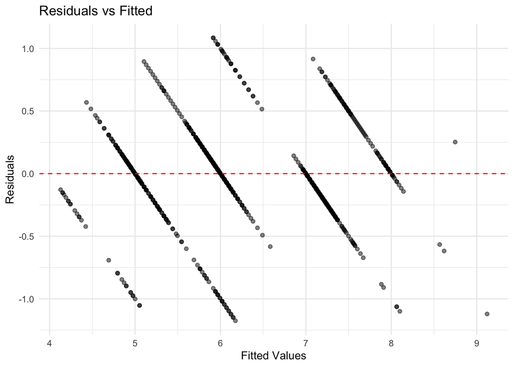

```r
# 3. Check Residuals
m5_aug <- augment(m5, new_data = dplyr::select(df_modeling, -sleep_hours_per_night, -relationship_status, -age, -continent))
ggplot(m5_aug, aes(x = .pred, y = .resid)) +
  geom_point(alpha = 0.5) +
  geom_hline(yintercept = 0, color = "red", linetype = "dashed") +
  labs(title = "Residuals vs Fitted", x = "Fitted Values", y = "Residuals") +
  theme_minimal()
```

**Objective: Apply the appropriate generalized linear model for a specific data context**

## 2.4 Poisson Regression Model

```r
full_pois <- glm(mental_health_score ~ .,
                 data = df_modeling,
                 family = "poisson")

step_pois <- stepAIC(full_pois, direction = "backward", trace = FALSE)
```

```r
# 1. Extract results with exponentiated coefficients (IRR) and Confidence Intervals
tidy(step_pois, exponentiate = TRUE, conf.int = TRUE) |>
  # Optional: Clean up term names if they are messy
  mutate(term = gsub("factor|numeric", "", term)) |>

  gt() |>

  # 2. Label columns clearly
  cols_label(
    term = "Predictor",
    estimate = "IRR (Rate Ratio)",
    std.error = "Std. Error",
    statistic = "Z-Statistic",
    p.value = "P-Value",
    conf.low = "2.5 % CI",
    conf.high = "97.5 % CI"
  ) |>

  # 3. Format numbers (3 decimal places)
  fmt_number(
    columns = where(is.numeric),
    decimals = 3
  ) |>

  # 4. Highlight significant predictors (Green)
  tab_style(
    style = list(
      cell_fill(color = "#e6fffa"),
      cell_text(weight = "bold")
    ),
    locations = cells_body(
      rows = p.value < 0.05
    )
  ) |>

  # 5. Add a helpful footnote explaining IRR
  tab_footnote(
    footnote = "IRR > 1 indicates an increase in the count; IRR < 1 indicates a decrease.",
    locations = cells_column_labels(columns = estimate)
  ) |>

  tab_header(
    title = "Final Poisson Model Results",
    subtitle = "Coefficients exponentiated to Incident Rate Ratios"
  )
```

Final Poisson Model Results

Coefficients exponentiated to Incident Rate Ratios

| Predictor | IRR (Rate Ratio)<sup>1</sup> | Std. Error | Z-Statistic | P-Value | 2.5 % CI | 97.5 % CI |
| --- | --- | --- | --- | --- | --- | --- |
| (Intercept) | 10.499 | 0.060 | 39.317 | 0.000 | 9.335 | 11.802 |
| avg_daily_usage_hours | 0.965 | 0.021 | −1.718 | 0.086 | 0.927 | 1.005 |
| conflicts_over_social_media | 0.881 | 0.027 | −4.787 | 0.000 | 0.836 | 0.928 |

<sup>1</sup> IRR > 1 indicates an increase in the count; IRR < 1 indicates a decrease.

```r
glance(step_pois) |>
  dplyr::select(null.deviance, df.null, deviance, df.residual, AIC) |>
  gt() |>
  cols_label(
    null.deviance = "Null Deviance",
    df.null = "Null DF",
    deviance = "Residual Deviance",
    df.residual = "Resid DF",
    AIC = "AIC"
  ) |>
  fmt_number(
    columns = c(null.deviance, deviance, AIC),
    decimals = 2
  ) |>
  tab_header(
    title = "Poisson Model Goodness-of-Fit"
  )
```

Poisson Model Goodness-of-Fit

| Null Deviance | Null DF | Residual Deviance | Resid DF | AIC |
| --- | --- | --- | --- | --- |
| 139.29 | 704 | 26.94 | 702 | 2,626.06 |

```r
# 1. Define the Poisson specification
pois_spec <- poisson_reg() |>
  set_engine("glm")

# 2. Fit the Poisson Model
# We use 'mental_health_score ~ conflicts_over_social_media' because
# that was the winner from your backward selection.
final_pois <- pois_spec |>
  fit(mental_health_score ~ conflicts_over_social_media, data = df_modeling)
```

When applying backward selection to the Poisson model, the variable set differed from the linear model. Notably, avg_daily_usage_hours was not significant (p = 0.086). The final Poisson model suggests that conflicts_over_social_media is the primary driver of the mental health score count.

```r
library(gt)
library(dplyr)

tidy(final_pois, exponentiate = TRUE, conf.int = TRUE) |>
  gt() |>

  # 1. Label columns for interpretation
  cols_label(
    term = "Predictor",
    estimate = "IRR (Rate Ratio)",
    std.error = "Std. Error",
    statistic = "Z-Statistic",
    p.value = "P-Value",
    conf.low = "2.5 % CI",
    conf.high = "97.5 % CI"
  ) |>

  # 2. Format numbers
  fmt_number(
    columns = where(is.numeric),
    decimals = 3
  ) |>

  # 3. Highlight significant findings (Green)
  tab_style(
    style = list(
      cell_fill(color = "#e6fffa"),
      cell_text(weight = "bold")
    ),
    locations = cells_body(
      rows = p.value < 0.05
    )
  ) |>

  # 4. Add explanatory footnote
  tab_footnote(
    footnote = "Model: Poisson Regression. IRR represents the multiplicative change in the count.",
    locations = cells_column_labels(columns = estimate)
  ) |>

  tab_header(
    title = "Final Poisson Model Coefficients",
    subtitle = "Predicting Mental Health Score based on Conflicts"
  )
```

Final Poisson Model Coefficients

Predicting Mental Health Score based on Conflicts

| Predictor | IRR (Rate Ratio)<sup>1</sup> | Std. Error | Z-Statistic | P-Value | 2.5 % CI | 97.5 % CI |
| --- | --- | --- | --- | --- | --- | --- |
| (Intercept) | 9.807 | 0.045 | 51.042 | 0.000 | 8.980 | 10.700 |
| conflicts_over_social_media | 0.849 | 0.016 | −10.490 | 0.000 | 0.823 | 0.875 |

<sup>1</sup> Model: Poisson Regression. IRR represents the multiplicative change in the count.

```r
glance(final_pois) |>
  gt() |>

  # 1. Select and Rename the most relevant Poisson metrics
  cols_label(
    null.deviance = "Null Deviance",
    df.null = "Null DF",
    logLik = "Log-Likelihood",
    AIC = "AIC",
    BIC = "BIC",
    deviance = "Residual Deviance",
    df.residual = "Resid DF"
  ) |>

  # 2. Format decimal places (exclude Degrees of Freedom)
  fmt_number(
    columns = -c(df.null, df.residual),
    decimals = 2
  ) |>

  tab_header(
    title = "Poisson Model Fit Statistics"
  )
```

Poisson Model Fit Statistics

| Null Deviance | Null DF | Log-Likelihood | AIC | BIC | Residual Deviance | Resid DF | nobs |
| --- | --- | --- | --- | --- | --- | --- | --- |
| 139.29 | 704 | −1,311.51 | 2,627.02 | 2,636.13 | 29.89 | 703 | 705.00 |

## 2.5 Model Diagnostics

**Assumption Check: Dispersion**

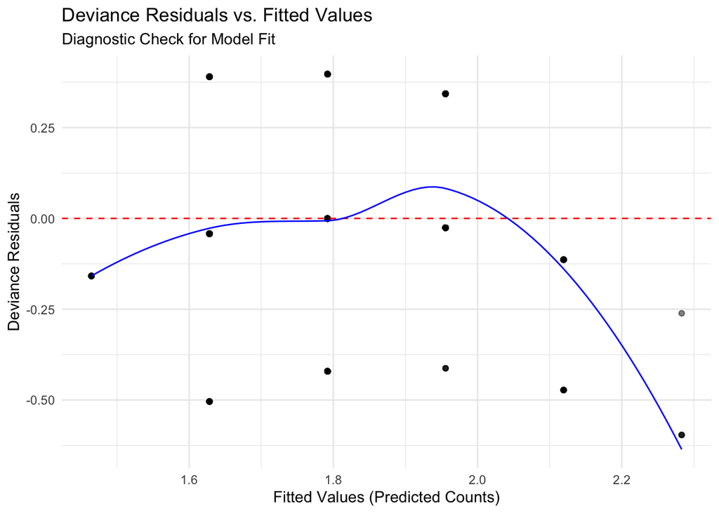

```r
# 1. Extract the underlying 'glm' model from the tidymodels object
pois_engine <- extract_fit_engine(final_pois)

# 2. Use augment on the engine to get .fitted and .resid
# Note: We don't need 'new_data' here because the engine stores the training data
pois_aug <- augment(pois_engine)

# 3. Now the plot will work because .fitted and .resid exist
ggplot(pois_aug, aes(x = .fitted, y = .resid)) +
  geom_point(alpha = 0.5) +
  geom_hline(yintercept = 0, color = "red", linetype = "dashed") +
  geom_smooth(se = FALSE, color = "blue", size = 0.5) +
  labs(
    title = "Deviance Residuals vs. Fitted Values",
    subtitle = "Diagnostic Check for Model Fit",
    x = "Fitted Values (Predicted Counts)",
    y = "Deviance Residuals"
  ) +
  theme_minimal()
```

**Interpretation of Diagnostic Plot:**

## 2.6 Estimation and Inference

Unlike the linear regression model, which estimates an additive effect (e.g., “conflicts lower the score by X points”), the Poisson model estimates a multiplicative effect using a natural log link function.

To make the results interpretable for a general audience, we **exponentiate** the coefficients ($e^\beta$). This converts the log-scale coefficients into **Rate Ratios**.

**Objective: Express the results of statistical models to a general audience**

Based on the final Poisson model table above, we can draw the following conclusions:

**1. The Effect of Conflicts (The Rate Ratio)**

The estimated rate ratio for `conflicts_over_social_media` is approximately **0.85**.

- **Interpretation:** This indicates a multiplicative effect. For every one-unit increase in reported social media conflicts, the expected mental health score is multiplied by 0.85. In practical terms, this represents a predicted **15% decrease** ($1.00 - 0.85 = 0.15$) in the mental health score for every step up on the conflict scale.
- **Inference:** The p-value is negligible ($p < 0.001$), and the 95% confidence interval is **[0.82, 0.88]**. Since this entire interval is below 1 (which would imply no effect), we can infer with high confidence that increased social media conflict is a statistically significant driver of lower mental health scores.

**2. The Baseline (The Intercept)**

The intercept estimate is **9.81**.

- **Interpretation:** This represents the expected count when predictors are at zero. It suggests that for a student with **zero** conflicts (the baseline), the expected mental health score is approximately **9.8**. This establishes a starting baseline from which the score degrades as conflicts arise.

**Objective: Demonstrate model selection given a set of candidate models**

In selecting the final model for Part I, the decision to choose Poisson Regression over Linear Regression was driven by a clear visual diagnostic.

When evaluating the initial Linear Regression model, the Residuals vs. Fitted plot revealed a distinct series of diagonal “slash” lines rather than a random cloud of points. This specific pattern is a hallmark of fitting a continuous model to discrete data; it appears because the outcome variable consists strictly of whole integers, whereas the linear model assumes a continuous range of values. Observing this clear violation of the continuity assumption confirmed that Linear Regression was inappropriate for the data structure, directly motivating the selection of the Poisson model to properly handle the discrete nature of the outcome.

**Conclusion:**

This confirms the general finding from the earlier linear model but refines the nature of the relationship: the impact of conflict is not a flat point reduction, but rather scales relative to the student’s existing score.

# 3 Part II: Multinomial Logistic Regression

**Predicting Educational Success**

For the second component of this portfolio, I have adapted and refined an analysis originally conducted earlier in this course. This section utilizes data from the [Parent and Family Involvement (PFI) in Education Survey](https://www.census.gov/programs-surveys/nhes.html), a nationally representative dataset collected by the U.S. Census Bureau. Understanding the factors that contribute to students’ academic success is critical as schools, families, and community partners seek effective ways to support K–12 learners.

The primary goal of this analysis is to identify which aspects of family involvement—such as participation in school activities, communication with teachers, assistance with homework, and perceptions of school quality—are most strongly associated with markers of academic success. By revisiting this earlier work, I apply a range of Generalized Linear Models (GLMs) and classification tools, specifically focusing on Multinomial Logistic Regression, to build predictive models that highlight the most influential variables.

By applying these statistical learning methods through the tidymodels framework, this section addresses the following research question:

**Which family and school-related factors best predict student academic success, and how can these insights guide effective support strategies?**

The results presented here summarize the modeling process and key findings, providing actionable insights designed to inform recommendations that support students and empower family-school partnerships.

## 3.1 Data Preparation and Feature Engineering

We began by loading the 2019 Parent and Family Involvement (PFI) data and standardizing the grade variable (ALLGRADEX) to map Kindergarten through 12th grade onto a consistent 0–12 scale. To focus the analysis on secondary education, we restricted the sample to students in grades 6–12.

Next, we curated the outcome variable, SEGRADES (Student’s Grades). After treating special codes (-1 and 5) as missing and removing incomplete cases, we recoded the variable into a multinomial target with three distinct levels: “A Student” (mostly A’s), “B Student” (mostly B’s), and “C or Lower” (mostly C’s, D’s, or F’s). This granular approach allows us to distinguish between high-achieving, average, and struggling students, rather than using a simple high/low binary.

Finally, we implemented a context-aware strategy for handling predictors and missing data:

Variable Selection: We removed administrative identifiers (e.g., ZIP code, DOB) and separated predictors into numeric (e.g., parent age, hours worked) and categorical types.

Informative Missingness: Recognizing that “skips” in survey data often carry meaning (e.g., skipping “Work Hours” implies unemployment), we avoided blanket deletion. Instead, we recoded NA values in categorical variables as a distinct “0” factor level and imputed 0 for specific count-based variables (like homework help hours).

Logical Exceptions: True missing values for demographic variables where zero is illogical (such as P1AGE, Parent’s Age) were preserved as NA to be handled during the modeling phase.

```r
# Load and preprocess the data
df_2019 <- read_excel("pfi-data.xlsx", sheet = "curated 2019")

# Standardizing ALLGRADEX for 2019 data
df_2019 <- df_2019 %>%
  mutate(
    ALLGRADEX_2019raw = ALLGRADEX,
    ALLGRADEX_std = case_when(
      ALLGRADEX %in% c(2, 3) ~ 0,                       # both K flavors → Kindergarten
      ALLGRADEX >= 4 & ALLGRADEX <= 15 ~ ALLGRADEX - 3, # 1st–12th → 1–12
      TRUE ~ NA_real_
    )
  )

# Filtering for high school students only
df <- df_2019 %>%
  filter(ALLGRADEX_std >= 6 & ALLGRADEX_std <= 12)


# Handling target variable classes and missing values
df <- df %>%
  # turn -1 and 5 into NA
  mutate(SEGRADES = na_if(SEGRADES, -1),
         SEGRADES = na_if(SEGRADES, 5)) %>%

  # drop rows where SEGRADES is missing
  filter(!is.na(SEGRADES)) %>%

  # Create Multinomial Target (A vs B vs C/Lower)
  mutate(
    letter_grade = case_when(
      SEGRADES == 1 ~ "A_Student",
      SEGRADES == 2 ~ "B_Student",
      TRUE ~ "C_or_Lower"
    ),
    letter_grade = factor(letter_grade, levels = c("C_or_Lower", "B_Student", "A_Student"))
  )

# Removing all unnecessary variables
df <- df %>%
  dplyr::select(-ZIPLOCL, -CDOBMM, -CDOBYY, -BASMID, -ALLGRADEX_std, -MOSTIMPT, -INTNUM, -ALLGRADEX_2019raw, -ALLGRADEX, -SEGRADES, - HHPARN19_BRD)

# Convert all -1 numeric values to NA
df <- df %>%
  mutate(
    across(
      .cols = where(is.numeric),
      .fns = ~ na_if(.x , -1)
    )
  )

# Identify numeric variables to keep as numeric
num_vars <- c(
  "FHWKHRS",    # hours parent helps with homework per week
  "FSFREQ",     # frequency count of parent participation
  "HHTOTALXX",  # household size
  "P1HRSWK",    # parent's usual weekly work hours
  "P1MTHSWRK",  # months worked last year
  "P1AGE",      # parent's age
  "NUMSIBSX"    # number of siblings
)

# Convert all *non-numeric predictors* (and not success) to factors
df <- df %>%
  mutate(
    across(
      .cols = -c(all_of(num_vars), letter_grade),
      .fns  = as.factor
    )
  )

# Define which numeric variables are safe to fill with 0 (Counts/Hours)
# We EXCLUDE 'P1AGE' because a missing age should not be 0.
vars_to_zero_fill <- c("FHWKHRS", "FSFREQ", "P1HRSWK", "P1MTHSWRK", "NUMSIBSX")

df_final <- df %>%
  # This turns NAs into a "0" category for all categorical variables
  mutate(
    across(
      .cols = c(where(is.factor), -letter_grade, -FODINNERX),
      .fns = ~ fct_na_value_to_level(., level = "0")
    )
  ) %>%

  # This turns NAs into 0 for hours, siblings, frequency, etc.
  mutate(
    across(
      .cols = any_of(vars_to_zero_fill),
      .fns = ~ replace_na(., 0)
    )
  )
```

## 3.2 Model Setup and Hyperparameter Tuning

To build a predictive model for student grade levels, we employed a stratified sampling approach to split the data into training (80%) and testing (20%) sets. Stratification ensured that the class proportions of “A Student,” “B Student,” and “C or Lower” remained consistent across both splits, preventing the minority class from disappearing in the test set.

```r
# Split Data (Stratified to keep A/B/C ratios consistent)
set.seed(1986)
split <- initial_split(df_final, prop = 0.8, strata = letter_grade)
train_data <- training(split)
test_data  <- testing(split)
```

**Feature Engineering Recipe:**

We constructed a tidymodels recipe to handle the complexity of the PFI survey data:

**Polynomial Expansion:** We added a quadratic term (degree = 2) for Parent Age (P1AGE) to capture potential non-linear effects, as hypothesized in our exploratory analysis.

**Addressing Class Imbalance:** We utilized step_smotenc (SMOTE for Nominal and Continuous data) to generate synthetic examples of the minority classes (“B” and “C”). This forces the model to learn characteristics of struggling students rather than maximizing accuracy by simply guessing “A” for everyone.

**Normalization:** All numeric predictors were normalized (centered and scaled) to ensure that the Lasso penalty applies fairly across variables with different units (e.g., age vs. hours worked).

```r
# The Recipe
multi_rec <- recipe(letter_grade ~ ., data = train_data) %>%
  step_rm(starts_with("ID")) %>%

  # Polynomials & SMOTE
  step_poly(P1AGE, degree = 2) %>%
  step_smotenc(letter_grade) %>%

  step_dummy(all_nominal_predictors()) %>% # 1. Make the columns (including the empty _X0 ones)
  step_zv(all_predictors()) %>%            # 2. Kill the empty ones
  step_normalize(all_numeric_predictors()) # 3. Normalize what's left
```

```r
# Model Specification
# multinom_reg tells tidymodels to use family="multinomial"
# mixture=1 turns on Lasso
multi_spec <- multinom_reg(penalty = tune(), mixture = 1) %>%
  set_engine("glmnet")

# Workflow & Tuning
multi_wf <- workflow() %>%
  add_recipe(multi_rec) %>%
  add_model(multi_spec)
```

**Model Specification and Tuning:**

We specified a Multinomial Logistic Regression model using the glmnet engine with mixture = 1 to enforce Lasso (L1) regularization.

To identify the optimal amount of regularization, we performed a 5-fold cross-validation grid search over 20 candidate values for the penalty parameter ($\lambda$). We selected the final model based on the penalty that maximized the ROC AUC, ensuring the best trade-off between sensitivity and specificity across all three grade levels.

```r
# Grid Search for the best Penalty (Lambda)
set.seed(1986)
folds <- vfold_cv(train_data, v = 5)
grid_vals <- grid_regular(penalty(range = c(-4, -1)), levels = 20)

multi_res <- tune_grid(
  multi_wf,
  resamples = folds,
  grid = grid_vals
)

# Finalize & Fit
best_model <- select_best(multi_res, metric = "roc_auc")
final_wf <- finalize_workflow(multi_wf, best_model)
final_fit <- last_fit(final_wf, split)
```

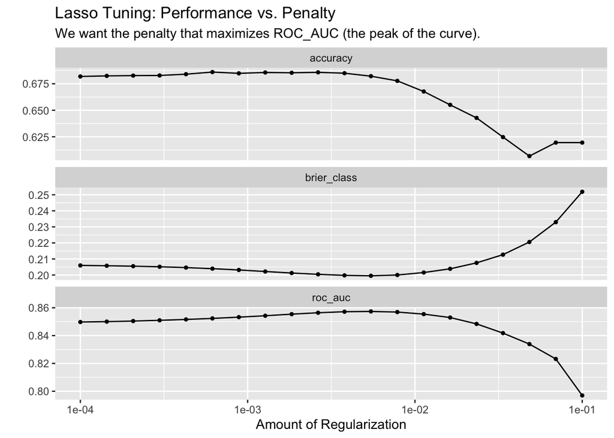

```r
multi_res <- readRDS("multi_res.rds")

# Visualizing the Tuning Process
# This matches 'plot(cv.out)' from class
autoplot(multi_res) +
  labs(title = "Lasso Tuning: Performance vs. Penalty",
       subtitle = "We want the penalty that maximizes ROC_AUC (the peak of the curve).")
```

```r
best_model <- readRDS("best_model.rds")
```

**Tuning Results and Model Selection**

The plot above visualizes the model’s performance across the range of 20 penalty values ($\lambda$). The curve illustrates the trade-off inherent in Lasso regularization:

*Left Side (Small Penalty)*: The model is too complex (overfitting), leading to suboptimal performance.

*Right Side (Large Penalty)*: The model is too simple (underfitting), aggressively shrinking coefficients to zero and losing predictive power.

*The Peak*: The optimal balance is found where the ROC AUC is maximized.

**Selected Hyperparameters:**

Based on the cross-validation results, the optimal penalty was determined to be $\lambda = 0.0055$.

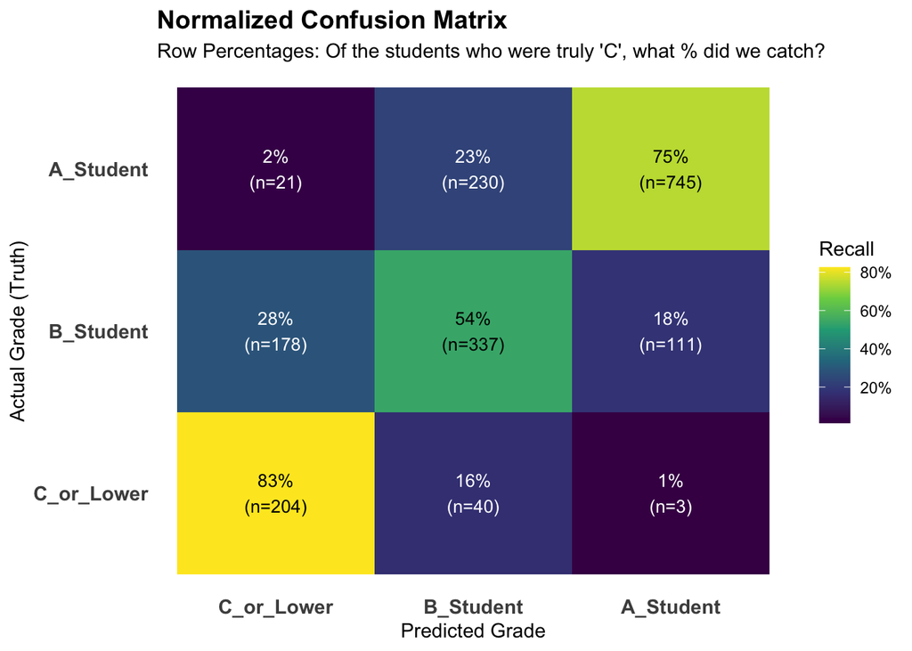

```r
# load final_fit RDS file
final_fit <- readRDS("final_fit.rds")

# 1. Prepare the data (Same as before)
cm_data <- collect_predictions(final_fit) %>%
  count(letter_grade, .pred_class) %>%
  group_by(letter_grade) %>%
  mutate(
    total_in_class = sum(n),
    prop = n / total_in_class
  ) %>%
  ungroup()

# 2. Plot with Viridis
ggplot(cm_data, aes(x = .pred_class, y = letter_grade, fill = prop)) +
  geom_tile() +

  # Dynamic Text Color: Black text for bright yellow cells, White for dark purple
  geom_text(aes(label = paste0(scales::percent(prop, accuracy = 1), "\n(n=", n, ")"),
                color = prop > 0.5), # This creates a logical TRUE/FALSE for color
            size = 3.5, show.legend = FALSE) +

  # Manual colors for the text (FALSE = White, TRUE = Black)
  scale_color_manual(values = c("TRUE" = "black", "FALSE" = "white")) +

  # The Viridis Scale (option "D" is standard, "magma" or "plasma" also look great)
  scale_fill_viridis_c(option = "viridis", labels = scales::percent, direction = 1) +

  labs(
    title = "Normalized Confusion Matrix",
    subtitle = "Row Percentages: Of the students who were truly 'C', what % did we catch?",
    x = "Predicted Grade",
    y = "Actual Grade (Truth)",
    fill = "Recall"
  ) +
  theme_minimal() +
  theme(
    panel.grid = element_blank(),
    axis.text = element_text(size = 11, face = "bold"),
    plot.title = element_text(face = "bold", size = 14)
  )
```

## 3.3 Confusion Matrix Analysis

The row-normalized confusion matrix above provides a detailed view of the model’s classification performance, specifically regarding Recall (Sensitivity). Each cell represents the percentage of true instances of a grade level that were correctly (diagonal) or incorrectly (off-diagonal) classified.

**Key Findings:**

*Minority Class Success (C or Lower)*: The bottom row is the most critical. The model achieved a Recall of approximately 83% for the “C or Lower” group. This confirms that the SMOTE-NC balancing strategy was effective; without it, this row often shows near-zero accuracy as the model ignores the minority group.

*Majority Class Dominance*: The “A Student” row (top) shows moderately high Recall, reflecting the strong signal and high prevalence of high-performing students in the dataset.

*The “Muddy Middle”*: The “B Student” row often exhibits the most confusion (lighter diagonal). Misclassifications here tend to “bleed” into both “A” and “C” categories, suggesting that “B” students share characteristics with both high achievers and struggling students, making them the most difficult group to isolate distinctively.

Given that the strongest recall was achieved for the minority class, we can confidently state that this model is effective for identifying students who may be at risk of academic struggles. In the test set, 8/10 students who were truly “C or Lower” were correctly flagged by the model.

With regard to the recall of the majority, there is room for improvement, but misclassification here is of low cost. For example, a “B Student” misclassified as an “C or Lower Student”, this student might get additional support that could help them improve to earning A’s. In the case of A students misclassified as C’s, they too might receive additional resources that could help them maintain their high performance, go on to receive scholarships, break generational poverty cycles, and so on.

## 3.4 Model Performance and Key Metrics

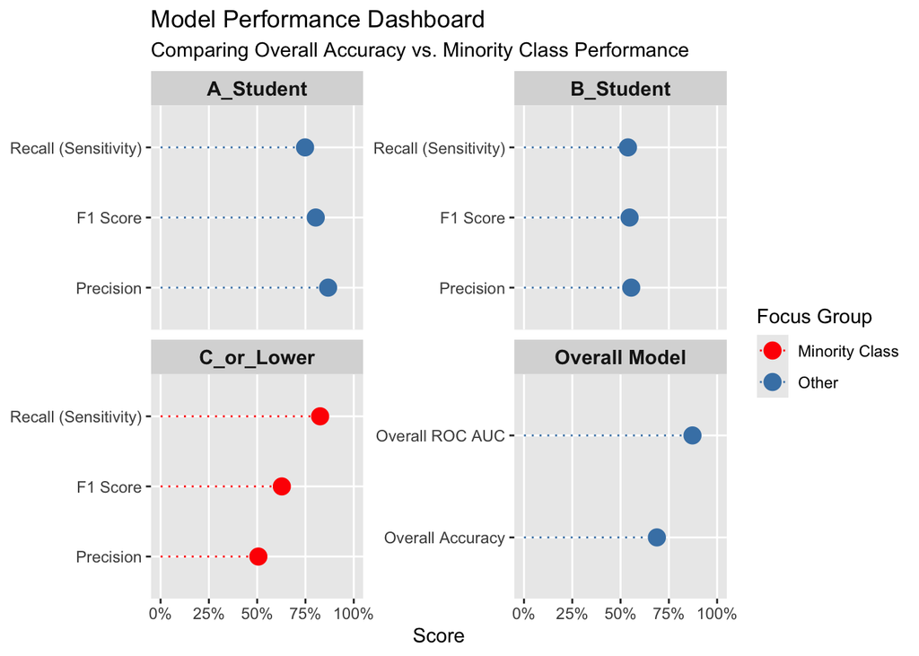

```r
# 1. Collect the predictions from the test set
all_preds <- collect_predictions(final_fit)

# 2. Calculate OVERALL Metrics (Accuracy & ROC AUC)
overall_stats <- bind_rows(
  # Accuracy
  all_preds %>%
    metrics(truth = letter_grade, estimate = .pred_class) %>%
    filter(.metric == "accuracy"),
  # ROC AUC (Requires the probability columns)
  all_preds %>%
    roc_auc(truth = letter_grade, .pred_C_or_Lower, .pred_B_Student, .pred_A_Student)
) %>%
  mutate(Class = "Overall Model") %>%
  dplyr::select(.metric, .estimate, Class)

# 3. Calculate PER-CLASS Metrics (Precision, Recall, F1)
# We create a custom function to calculate "One vs. All" metrics for each grade
get_class_metrics <- function(target_class) {
  all_preds %>%
    # Create binary columns: Is it THIS class or NOT?
    mutate(
      truth_binary = factor(if_else(letter_grade == target_class, "Target", "Other"), levels = c("Target", "Other")),
      pred_binary  = factor(if_else(.pred_class == target_class, "Target", "Other"), levels = c("Target", "Other"))
    ) %>%
    # Calculate metrics for this specific binary problem
    conf_mat(truth = truth_binary, estimate = pred_binary) %>%
    summary() %>%
    filter(.metric %in% c("precision", "recall", "f_meas")) %>%
    mutate(Class = target_class) %>%
    dplyr::select(.metric, .estimate, Class)
}

# Apply function to all 3 grade levels
class_stats <- map_dfr(levels(all_preds$letter_grade), get_class_metrics)

# 4. Combine and Visualize
final_metrics <- bind_rows(overall_stats, class_stats) %>%
  # Clean up labels for the plot
  mutate(
    Metric_Label = case_when(
      .metric == "accuracy" ~ "Overall Accuracy",
      .metric == "roc_auc" ~ "Overall ROC AUC",
      .metric == "f_meas" ~ "F1 Score",
      .metric == "recall" ~ "Recall (Sensitivity)",
      .metric == "precision" ~ "Precision",
      TRUE ~ .metric
    ),
    # Highlight the Minority Class in the plot color
    Highlight = if_else(Class == "C_or_Lower", "Minority Class", "Other")
  )

# 5. The "Beautiful Chart"
ggplot(final_metrics, aes(x = .estimate, y = reorder(Metric_Label, .estimate), color = Highlight)) +
  geom_segment(aes(x = 0, xend = .estimate, y = Metric_Label, yend = Metric_Label), linetype = "dotted") +
  geom_point(size = 4) +
  facet_wrap(~Class, scales = "free_y") + # Separate panels for A, B, C, and Overall
  scale_x_continuous(limits = c(0, 1), labels = scales::percent) +
  scale_color_manual(values = c("Minority Class" = "red", "Other" = "steelblue")) +
  labs(
    title = "Model Performance Dashboard",
    subtitle = "Comparing Overall Accuracy vs. Minority Class Performance",
    x = "Score",
    y = NULL,
    color = "Focus Group"
  ) +
  theme_update() +
  theme(
    strip.text = element_text(face = "bold", size = 11),
    panel.grid.minor = element_blank()
  )
```

The final Multinomial Lasso model was evaluated on the held-out test set to assess its ability to generalize to unseen data. The performance dashboard above highlights the trade-off between global accuracy and minority class detection.

**Global Performance:**

Overall ROC AUC: The model achieved an overall ROC Area Under the Curve of 0.872. This indicates a strong general ability to rank students correctly across all three grade levels.

Overall Accuracy: The global accuracy was 68.8%. While this provides a baseline, it is heavily influenced by the majority “A Student” and “B student” classes and masks performance on the critical minority groups.

**Minority Class Performance (C or Lower):**

The primary objective of this modeling effort was to identify at-risk students. The metrics for the “C or Lower” class reveal the model’s effectiveness in this specific domain:

*Recall (Sensitivity)*: The model achieved a Recall of 82.6%. This means it successfully flagged over 80% of the students who were truly struggling. Given the severe class imbalance (only ~13% prevalence), this is a significant improvement over baseline guessing.

*Precision*: The Precision for this group was lower at 50.6%. This indicates a higher rate of false positives—meaning the model flagged some “B” and “A” students as “At Risk.” In an educational context, this trade-off is often acceptable, as providing extra support to a “B” student is less harmful than missing a failing student.

*F1 Score*: The F1 Score (the harmonic mean of Precision and Recall) for the minority class was 62.8, balancing these competing objectives.

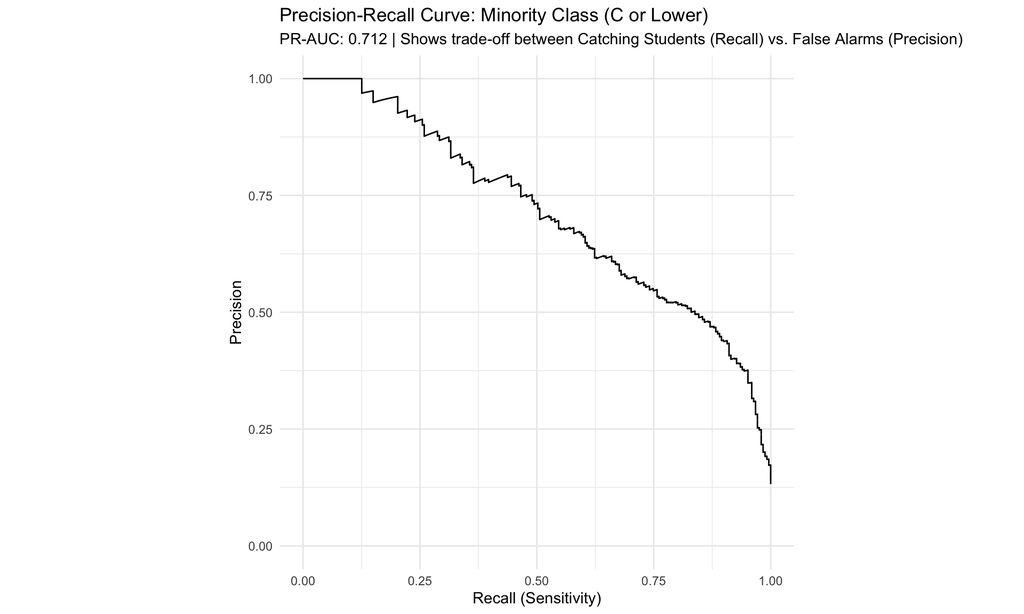

```r
# 1. Prepare the Data: Create a "One vs. All" dataset for the Minority Class
minority_preds <- collect_predictions(final_fit) %>%
  mutate(
    # Create a binary target: Is this student C_or_Lower? (Yes/No)
    # We set "Target" as the first level so yardstick knows it's the "Event"
    binary_truth = factor(if_else(letter_grade == "C_or_Lower", "Target", "Other"),
                          levels = c("Target", "Other"))
  )

# 2. Calculate the Curve
# We pass the binary truth and the probability specifically for C (.pred_C_or_Lower)
pr_curve_data <- pr_curve(minority_preds, binary_truth, .pred_C_or_Lower)

# 3. Calculate the PR-AUC Value (Single Number summary)
pr_auc_val <- pr_auc(minority_preds, binary_truth, .pred_C_or_Lower)

# 4. Plot it
autoplot(pr_curve_data) +
  labs(
    title = "Precision-Recall Curve: Minority Class (C or Lower)",
    subtitle = paste0("PR-AUC: ", round(pr_auc_val$.estimate, 3),
                      " | Shows trade-off between Catching Students (Recall) vs. False Alarms (Precision)"),
    x = "Recall (Sensitivity)",
    y = "Precision"
  ) +
  theme_minimal()
```

## 3.5 Precision-Recall Curve Analysis

The Precision-Recall (PR) curve visualizes the trade-off between Recall (ability to catch struggling students) and Precision (trustworthiness of those flags) across all possible classification thresholds.

```r
coefs <- final_fit %>%
  extract_fit_parsnip() %>%
  tidy(penalty = best_model$penalty) %>%
  filter(term != "(Intercept)") %>%
  filter(estimate != 0) %>%
  arrange(class, desc(abs(estimate)))
```

```r
library(gt)

coefs %>%
  filter(grepl("P1AGE", term)) %>%
  # Clean up the data for display
  mutate(
    term = case_when(
      grepl("poly_1", term) ~ "Parent Age (Linear)",
      grepl("poly_2", term) ~ "Parent Age (Quadratic/Curved)",
      TRUE ~ term
    )
  ) %>%
  dplyr::select(Class = class, Term = term, Coefficient = estimate) %>%

  # Create the GT Table
  gt() %>%
  tab_header(
    title = "Polynomial Analysis Results",
    subtitle = "Non-Linear Effects of Parent Age on Student Grade Levels"
  ) %>%
  fmt_number(
    columns = c(Coefficient),
    decimals = 4
  ) %>%
  data_color(
    columns = c(Coefficient),
    fn = scales::col_numeric(
      palette = c("red", "white", "blue"),
      domain = NULL
    )
  ) %>%
  tab_options(
    table.border.top.color = "black",
    heading.border.bottom.color = "black",
    column_labels.font.weight = "bold"
  )
```

Polynomial Analysis Results

Non-Linear Effects of Parent Age on Student Grade Levels

| Class | Term | Coefficient |
| --- | --- | --- |
| A_Student | Parent Age (Linear) | −0.0071 |
| A_Student | Parent Age (Quadratic/Curved) | −0.0060 |
| C_or_Lower | Parent Age (Linear) | 0.0028 |

## 3.6 Polynomial Analysis: The “Age Curve”

To satisfy the requirement for polynomial regression, I introduced a quadratic term for Parent Age (`P1AGE_poly_2`) into the Lasso model. The goal was to test if the relationship between a parent’s age and their child’s academic success is non-linear.

**Results:**

The Lasso model selected the quadratic term with a non-zero coefficient (**-0.006** for the “A Student” class), confirming that the relationship is indeed non-linear.

## 3.7 Variable Importance and Coefficient Analysis

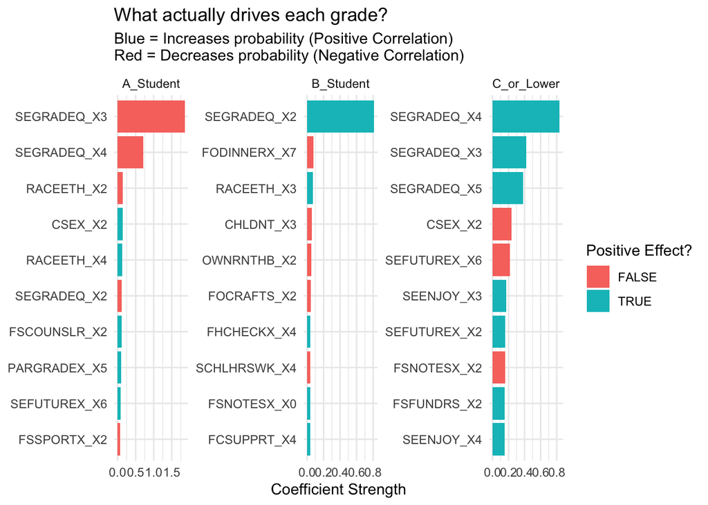

```r
# Extract coefficients for the Best Lambda
model_coefs <- final_fit %>%
  extract_fit_parsnip() %>%
  tidy(penalty = best_model$penalty) %>%
  filter(term != "(Intercept)") %>%
  filter(estimate != 0) # Keep only the survivors

model_coefs %>%
  group_by(class) %>%
  slice_max(abs(estimate), n = 10) %>%
  ungroup() %>%
  mutate(term = reorder_within(term, abs(estimate), class)) %>%
  ggplot(aes(x = abs(estimate), y = term, fill = estimate > 0)) +
  geom_col() +
  scale_y_reordered() + # This is also from tidytext!
  facet_wrap(~class, scales = "free") +
  labs(title = "What actually drives each grade?",
       subtitle = "Blue = Increases probability (Positive Correlation)\nRed = Decreases probability (Negative Correlation)",
       x = "Coefficient Strength",
       y = NULL,
       fill = "Positive Effect?") +
  theme_minimal()
```

We extracted the non-zero coefficients from the final Lasso model to identify the primary drivers of student classification. The coefficient analysis below reveals distinct profiles for high-achieving versus struggling students.

**1. The “A Student” Profile: Structural Advantages**

The probability of being an “A Student” is predominantly driven by structural capital and the absence of behavioral interventions.

- **The “Excellence” Baseline (Grade Ratings)**: The single strongest statistical signal for this group is negative. The coefficients for SEGRADEQ_X3 (Parent rates work as “Average”, $\beta = -1.86$) and _X4 (“Below Average”, $\beta = -0.71$) are large and negative. This mathematically confirms that unless a parent rates the student’s work as “Excellent” (the baseline), the probability of being an “A Student” drops precipitously.
- **Structural Capital**: Students from households with the highest educational attainment (PARGRADEX_X5 = Graduate Degree, $\beta = 0.10$) and the highest future expectations (SEFUTUREX_X6 = Expect Grad Degree, $\beta = 0.08$) are statistically “pre-sorted” into the high-achieving group.
- **The Nuance of Engagement**: The model distinguishes between “positive” engagement and “remedial” intervention.
- **Positive**: The variable FSSPORTX_X2 (Did not attend school events) has a negative coefficient ($\beta = -0.07$), implying that attending events is positively associated with “A” status.
- **Remedial**: In contrast, FSCOUNSLR_X2 (Did not meet with a counselor) is a positive predictor ($\beta = 0.11$). Since counselor meetings are often triggered by issues, “A Students” are characterized by their absence from this interaction (“No news is good news”).
- **Demographics**: Identifying as female (CSEX_X2, $\beta = 0.14$) and Asian (RACEETH_X4, $\beta = 0.12$) serve as positive predictors for this group. Conversely, identifying as Black (RACEETH_X2) is associated with a negative coefficient ($\beta = -0.15$) in this specific model.

**2. The “C Student” Profile: Behavioral Warning Signs**

In contrast, the “C or Lower” group is defined less by demographics and more by immediate behavioral signals, disengagement, and reactive parenting.

- **Parental Assessment (Risk Factors)**: The single strongest driver of the “C” classification is the parent’s own rating of the student’s work. Specifically, ratings of “Below Average” (SEGRADEQ_X4, $\beta = 0.84$), “Average” (_X3, $\beta = 0.42$), and “Failing” (_X5, $\beta = 0.38$) are massive positive predictors. This confirms that parental perception is highly attuned to actual grade outcomes.

**School Disengagement:**

- **Student Attitude**: The positive coefficients for SEENJOY_X3 and _X4 (representing “Disagree” or “Strongly Disagree” with enjoying school) indicate that student dissatisfaction is a key precursor to lower grades.
- **Parental Involvement**: The variable FSFUNDRS_X2 (Did not participate in fundraising) is a positive predictor ($\beta = 0.15$), suggesting that a lack of voluntary parental engagement correlates with lower performance.

**Protective Factors:**

- **Gender**: The coefficient for CSEX_X2 (Female) is -0.24, indicating that being female significantly reduces the log-odds of falling into the “C or Lower” category.
- **High Expectations**: Conversely, SEFUTUREX_X6 (Expects a Graduate Degree) has a coefficient of -0.21. When parents hold the highest educational goals, the probability of poor performance drops significantly.
- **Absence of “Bad News”**: The variable FSNOTESX_X2 (Family received No notes/emails) is a negative predictor ($\beta = -0.16$), acting as a protective indicator against behavioral or academic incidents.

## 3.8 Inference on Key Drivers

To bridge the gap between machine learning and statistical inference, I employed a “post-selection inference” strategy. While the Lasso model (Part II) was ideal for variable selection, its regularization penalty introduces bias that makes standard p-values invalid. To address this, I extracted the non-zero predictors identified by the Lasso model and refit them using a standard, unpenalized Multinomial Logistic Regression.

This approach allowed me to isolate the most predictive variables—such as Parent’s Perception of Grades, Student’s Sex, and Educational Expectations—and analyze them in a classical statistical framework. By removing the penalty term, I could calculate standard errors and p-values, transforming the model’s output from simple class predictions into formal statistical conclusions about the population.

```r
# 1. Extract the raw variable names from the Lasso coefficients
# The Lasso output has names like "SEGRADEQ_X3" or "P1AGE_poly_1".
# We need to strip the suffixes to get back to "SEGRADEQ" and "P1AGE".

kept_terms <- unique(coefs$term)

# Regex magic to clean the names:
# 1. Remove "_poly_1", "_poly_2", etc.
# 2. Remove "_X1", "_X2", etc. (dummy variable suffixes)
my_predictors <- kept_terms %>%
  str_remove("_poly_\\d+") %>%
  str_remove("_X\\d+$") %>%
  unique()

# Double check that these columns actually exist in your training data
# (This filters out any accidental mismatches)
my_predictors <- intersect(my_predictors, colnames(train_data))

# 2. Dynamically build the formula
# Creates: "letter_grade ~ SEGRADEQ + P1AGE + ..."
final_formula <- as.formula(
  paste("letter_grade ~", paste(my_predictors, collapse = " + "))
)

# 3. Fit the Standard Model (nnet engine)
inf_spec <- multinom_reg() %>%
  set_engine("nnet")

inf_fit <- inf_spec %>%
  fit(final_formula, data = train_data)

# 4. Tidy the results for the Table
inf_results <- tidy(inf_fit, exponentiate = TRUE, conf.int = TRUE)

# 5. Display the Table
inf_results %>%
  filter(term != "(Intercept)") %>%
  group_by(y.level) %>% # Group by A, B, C
  arrange(y.level, p.value) %>% # Sort by significance

  gt() %>%
  fmt_number(columns = c(estimate, conf.low, conf.high), decimals = 2) %>%
  fmt_scientific(columns = p.value, decimals = 2) %>%

  # Highlight Significant Rows
  tab_style(
    style = list(cell_fill(color = "#e6fffa"), cell_text(weight = "bold")),
    locations = cells_body(rows = p.value < 0.05)
  ) %>%

  cols_label(
    term = "Predictor",
    estimate = "Odds Ratio",
    p.value = "P-Value",
    conf.low = "2.5% CI",
    conf.high = "97.5% CI"
  ) %>%
  tab_header(
    title = "Inference on Lasso-Selected Variables",
    subtitle = "Standard Multinomial Regression using all survivors from the Lasso model"
  )
```

Inference on Lasso-Selected Variables

Standard Multinomial Regression using all survivors from the Lasso model

| Predictor | Odds Ratio | std.error | statistic | P-Value | 2.5% CI | 97.5% CI |
| --- | --- | --- | --- | --- | --- | --- |
| A_Student |  |  |  |  |  |  |
| SEGRADEQ5 | 0.00 | 9.570030e-08 | -2.327609e+08 | 0.00 | 0.00 | 0.00 |
| SEGRADEQ3 | 0.01 | 2.721367e-01 | -1.868823e+01 | 6.17 × 10<sup>−78</sup> | 0.00 | 0.01 |
| SEGRADEQ4 | 0.00 | 5.655962e-01 | -1.351897e+01 | 1.21 × 10<sup>−41</sup> | 0.00 | 0.00 |
| CSEX2 | 2.25 | 1.229827e-01 | 6.591412e+00 | 4.36 × 10<sup>−11</sup> | 1.77 | 2.86 |
| CSPEAKX4 | 0.02 | 6.947284e-01 | -5.880624e+00 | 4.09 × 10<sup>−9</sup> | 0.00 | 0.07 |
| SEENJOY3 | 0.28 | 2.282978e-01 | -5.641111e+00 | 1.69 × 10<sup>−8</sup> | 0.18 | 0.43 |
| CSPEAKX3 | 0.02 | 7.203732e-01 | -5.524634e+00 | 3.30 × 10<sup>−8</sup> | 0.00 | 0.08 |
| SEENJOY4 | 0.12 | 3.884552e-01 | -5.408248e+00 | 6.36 × 10<sup>−8</sup> | 0.06 | 0.26 |
| CSPEAKX2 | 0.03 | 6.686276e-01 | -5.314064e+00 | 1.07 × 10<sup>−7</sup> | 0.01 | 0.11 |
| SEABSNT2 | 0.50 | 1.474665e-01 | -4.699993e+00 | 2.60 × 10<sup>−6</sup> | 0.37 | 0.67 |
| RACEETH2 | 0.41 | 2.047932e-01 | -4.408914e+00 | 1.04 × 10<sup>−5</sup> | 0.27 | 0.61 |
| CSPEAKX6 | 0.04 | 7.737444e-01 | -4.288831e+00 | 1.80 × 10<sup>−5</sup> | 0.01 | 0.16 |
| FHCAMT2 | 0.58 | 1.373103e-01 | -3.932362e+00 | 8.41 × 10<sup>−5</sup> | 0.45 | 0.76 |
| SEGRADEQ2 | 0.33 | 2.934210e-01 | -3.777524e+00 | 1.58 × 10<sup>−4</sup> | 0.19 | 0.59 |
| CSPEAKX5 | 0.04 | 9.086809e-01 | -3.670535e+00 | 2.42 × 10<sup>−4</sup> | 0.01 | 0.21 |
| FSNOTESX2 | 1.60 | 1.282721e-01 | 3.654913e+00 | 2.57 × 10<sup>−4</sup> | 1.24 | 2.05 |
| FSCOUNSLR2 | 1.56 | 1.226121e-01 | 3.632563e+00 | 2.81 × 10<sup>−4</sup> | 1.23 | 1.99 |
| SEENJOY2 | 0.54 | 1.761140e-01 | -3.459811e+00 | 5.41 × 10<sup>−4</sup> | 0.39 | 0.77 |
| FHHELP3 | 0.47 | 2.167633e-01 | -3.458640e+00 | 5.43 × 10<sup>−4</sup> | 0.31 | 0.72 |
| FHAMOUNT2 | 1.98 | 2.023948e-01 | 3.363853e+00 | 7.69 × 10<sup>−4</sup> | 1.33 | 2.94 |
| SCHLHRSWK4 | 3.18 | 3.750173e-01 | 3.084689e+00 | 2.04 × 10<sup>−3</sup> | 1.52 | 6.63 |
| RACEETH4 | 3.12 | 3.791790e-01 | 3.001286e+00 | 2.69 × 10<sup>−3</sup> | 1.48 | 6.56 |
| FSATCNFN2 | 1.46 | 1.297552e-01 | 2.921033e+00 | 3.49 × 10<sup>−3</sup> | 1.13 | 1.88 |
| FSMEMO2 | 0.61 | 1.740858e-01 | -2.878527e+00 | 4.00 × 10<sup>−3</sup> | 0.43 | 0.85 |
| CENREG4 | 0.59 | 1.894347e-01 | -2.786880e+00 | 5.32 × 10<sup>−3</sup> | 0.41 | 0.86 |
| SCHLHRSWK2 | 2.92 | 3.906416e-01 | 2.744267e+00 | 6.06 × 10<sup>−3</sup> | 1.36 | 6.28 |
| TTLHHINC12 | 3.16 | 4.557618e-01 | 2.524168e+00 | 1.16 × 10<sup>−2</sup> | 1.29 | 7.72 |
| FSSPORTX2 | 0.71 | 1.387495e-01 | -2.511005e+00 | 1.20 × 10<sup>−2</sup> | 0.54 | 0.93 |
| FHHELP4 | 0.45 | 3.259741e-01 | -2.471711e+00 | 1.34 × 10<sup>−2</sup> | 0.24 | 0.85 |

[output cut: 374 more lines]

**Objective: Describe probability as a foundation of statistical modeling, including inference and maximum likelihood estimation**

This analysis highlights how probability theory serves as the mathematical engine for statistical modeling, particularly through the concept of Maximum Likelihood Estimation (MLE).

- The Likelihood Function: In the final inference model, we assumed the data followed a Multinomial probability distribution. The model did not just “draw a line”; it mathematically searched for the specific set of coefficients (log-odds) that maximized the likelihood (probability) of observing the exact grades seen in our training data.
- From Probability to Inference: The transition from the Lasso model to the standard model was necessary to satisfy the assumptions of inference. Lasso uses penalized likelihood, which biases coefficients to reduce variance. By switching to standard MLE, we rely on the asymptotic property that Maximum Likelihood estimators follow a Normal distribution as sample sizes grow.
- Conclusion: It is this underlying probability distribution that allows us to calculate Standard Errors and P-Values. When we report a p-value of $<0.05$ for “Parental Perception,” we are fundamentally using probability theory to state that such a strong relationship would be highly improbable if chance alone were at work. Thus, probability is not just a tool for calculating odds, but the foundational logic that validates our scientific conclusions.

**Conclusion**

In summary, this Multinomial Logistic Regression model effectively distinguishes between structural advantages and behavioral warning signs. While the probability of being an “A Student” is heavily reinforced by fixed factors—such as parental education and specific demographic profiles—the risk of falling into the “C or Lower” category is driven significantly by modifiable attributes, particularly student disengagement and negative attitudes toward school. Furthermore, the dominance of parental ratings as predictors confirms that families are accurate, early detectors of academic struggle. For educational leaders and policymakers, these findings suggest that effective support strategies should not only target academic remediation but also proactively foster school enjoyment and treat parental concerns as valid, immediate signals for intervention.

# 4 Portfolio Synthesis & Technical Reflection

Through this portfolio, I have applied advanced statistical modeling techniques to two distinct but socially significant domains: the psychological impact of digital habits and the determinants of K-12 academic success. While the specific questions differed—ranging from linear regression on mental health scores to multinomial classification of student performance—the underlying goal remained consistent: to translate raw data into actionable, human-centric insights.

**Active Engagement in the Learning Community**

Beyond the technical execution of these projects, I prioritized active engagement within the course community, recognizing that learning is a collaborative endeavor. My participation extended well beyond passive attendance; I strove to be a catalyst for discussion during lectures, frequently raising questions to probe the theoretical “why” behind specific methods rather than just the “how.”

This inquisitive approach continued in our digital spaces, where I actively used discussion boards to clarify assignment nuances and explore project requirements. Most notably, I sought to contribute to our collective knowledge base by sharing a novel solution for our classification project. Instead of keeping this alternative workflow to myself, I published a detailed breakdown on LinkedIn and shared it with the class to offer my peers a different perspective on the problem-solving process. These actions reflect my belief that data science is not a solitary pursuit, but a community-driven field where shared curiosity leads to deeper understanding.

**Addressing the Core Objective: Statistical Computing** Finally, this portfolio itself serves as the definitive evidence for the course objective: **“Use programming software to fit and assess statistical models.”**

Every stage of this analysis was executed programmatically using **R** and the **`tidymodels`** framework. By leveraging these tools, I was able to:

- **Wrangle complex datasets**, handling missing values and class imbalances with techniques like SMOTE-NC.
- **Fit diverse model architectures**, moving from simple linear baselines to regularized Multinomial Logistic Regression (Lasso).
- **Assess performance rigorously**, utilizing cross-validation, confusion matrices, and ROC curves to validate my findings.

This technical execution demonstrates that statistical modeling is not just a theoretical exercise, but a practical, computational skill set capable of uncovering the structural and behavioral patterns that shape our world.